# TP LEROY

Tommy Tankhapanya Chloé Landais Guibert Samuel

26/01/2021

# Régression linéaire multiple, points influents et atypiques

#### Nous allons réaliser une étude sur une base de données qui reprend des informations sur des habitations de Wake County en Caroline du Nord USA. Le compté de Wake est l’endroit où se trouve Raleigh, la capitale de l’état de Caroline du Nord. Sur le plan démographique, la ville connaît une croissance exponentiel. En effet, la “ville des chênes” a connu une hausse de 31.18% de sa population depuis 2000. Cela signifie que de nombreuses maisons sont sortis de terre assez récemment.

#### Notre objectif dans cette étude est de déterminer les différents facteurs qui influent sur la valeur de l’habitation dans cette région. Cette étude pourrait être utile pour un agent immobilier de la région qui cherche à estimer la valeur d’un bien immobilier.

#### Notre population s’élève à 100 maisons et nous disposons de 11 variables :

- ID: numéro de l’habitation.
- Total: la valeur totale de la propriété en dollars.
- YearBuilt: l’année de construction de l’habitation.
- SqFt: la surface de l’habitation en feet au carré.
- Story: le nombre d’étages de l’habitation.
- Acres: le nombre de demi-hectare.
- NoBaths: le nombre de salles de bain dans l’habitation.
- Fireplaces: le nombre de cheminées dans l’habitation.
- Land: la valeur du terrain en dollars.
- Building: la valeur du bâtiment de l’habitation en dollars.
- Zip: le code zip de la propriété.

#### Notre méthodologie est la suivante : nous avons décidé de retirer les variables “ID”,“ZIP” et “Land” car les deux premières n’apportent pas d’informations exploitables. Quant à la dernière, Land est une variable créée à partir d’une autre variable, ainsi elle n’apporte pas d’informations supplémentaires.

#### Concernant les valeurs manquantes, une seule s’était glissé dans notre jeu de donnée. Nous avons décidé de ne pas la supprimer mais de la remplacer par la valeur de la médiane. Le remplacement par la médiane permet de ne pas biaisé notre jeu de données. Pour certains graphiques, nous avons décidé de regrouper certaines données en classe afin d’avoir une lecture plus facile.

# Prix des maisons dans notre jeu de données

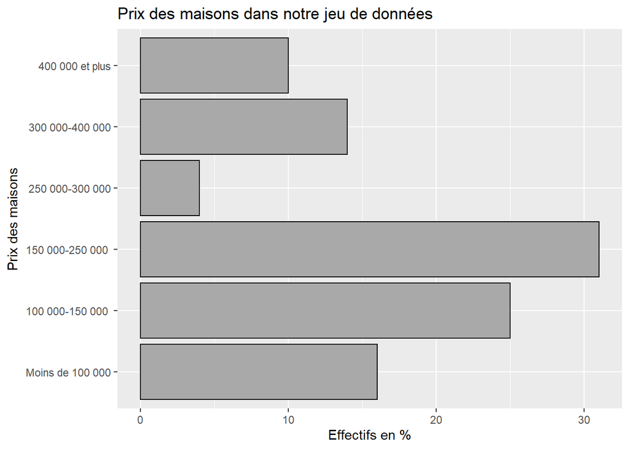

```
##    Min. 1st Qu.  Median    Mean 3rd Qu.    Max.
##   32184  123952  166494  258574  274050 4904102
```

```
##
##  Moins de 100 000  100 000-150 000   150 000-250 000    250 000-300 000
##              0.16              0.25              0.31              0.04
##   300 000-400 000   400 000 et plus
##              0.14              0.10
```

#### Au sein de notre population de maisons, le prix des maisons est assez hétérogène. En effet, la maison la moins onéreuse coûte seulement 32 184$ alors que la plus coûteuse est estimé à près de 5 millions de dollars.

#### Le prix moyen des maisons est de 258 574 $ mais cette moyenne ne rélfète pas la réalité de l’échantillon car les maisons très cheres influent grandement sur la moyenne. Ainsi, pour plus de visibilité sur les graphiques et afin de supprimer les biais. Nous avons décidé de supprimer temporairement deux individus : les deux maisons les plus onéreuses.

```
##    Min. 1st Qu.  Median    Mean 3rd Qu.    Max.
##   32184  123145  161998  202444  260234  523366
```

#### Avec notre échantillon sans ces deux individus la moyenne est de 202 444$.

## Pourquoi une maison coûte t-elle plus ou moins chère que les autres ?

```
##   YearBuilt SqFt Story Acres NoBaths Fireplaces   Total Building
## 1      2003 1404   1.0 39.38       2          0 4904102   106352
## 2      1989 4650   1.5  0.49       3          1 1113750   634230
## 3      1965  816   1.0  0.39       1          0   32184    22184
```

#### Il est important de noter que les maisons les plus chères n’ont pas de cheminées ou n’en possèdent qu’une seule.

## L’année de construction est-elle un facteur déterminant du prix des maisons en Caroline du Nord ?

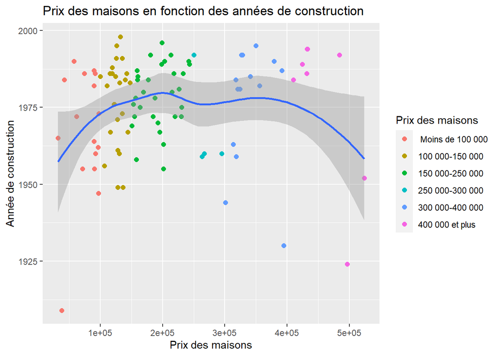

```
##    Min. 1st Qu.  Median    Mean 3rd Qu.    Max.
##    1909    1966    1981    1976    1987    1998
```

#### 50 % des maisons ont été construiste après 1981. D’après le graphique, il ne semble pas y avoir de lien entre l’année de construction et le prix des habitations.

#### Cependant,le contexte géographique est primodriale, en effet Raleigh et ses allentours ont connu une croissance démographique exponentielle depuis 1959 , cette apport de main d’oeuvres à dû nécessiter la constructions de nombreux logements. C’est pourquoi nous avons décider d’étudier la population en deux groupes. Le premier contient les habitations construites avant 1982 et le second les autres.

```
## [1] -0.1649438
```

```
## [1] 0.2630599
```

#### Les habitations d’avant 1982 ont une corrélation négative de -0.17 et celles d’après 1982 est de 0.26. Ainsi, on observe que les maisons d’après 1982 sont davantage correlés que les maisons d’avant 1982. Cette petite corrélation positive indique que plus l’année de construction augmente plus le prix augmente pour les maisosn d’après 1982. Il est a noté toutefois que cette corrélation n’est pas très elevée.

## La surface de l’habitation en pieds carrés a-t-elle une influence sur la valeur de l’habitation ?

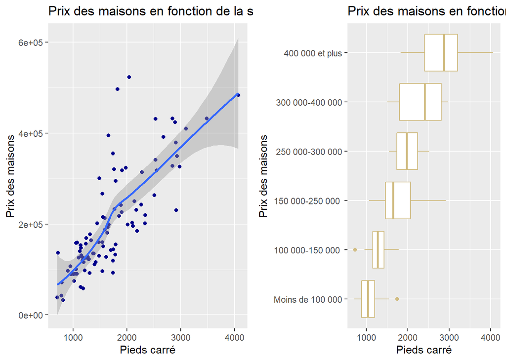

```
## [1] 0.7978614
```

#### Pour l’ensemble des habitations on observe une forte corrélation de 0.80 entre le prix de l’habitation et sa surface en pieds carrés. On peut donc en déduire que la variable sqFt influe grandement sur le prix total (pvaleur<2.2*10e-16). #### Cependant, pour les maisons d’après 1982, cette corrélation est encore plus forte (0.93) alors que pour les maisons d’avant 1982 elle est seulement de 0.59.

```
##   Corrélation générale Avant 1982 Après 1982
## 1                0.798      0.589      0.928
```

## Le nombre de cheminées est-il un facteur déterminant sur la valeur de l’habitation ?

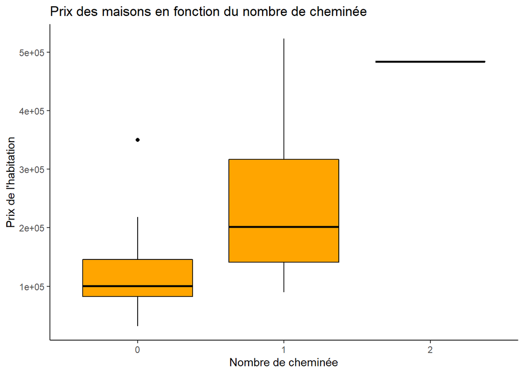

```
##   Corrélation générale Avant 1982 Après 1982
## 1                0.486      0.508      0.452
```

#### D’après les résultats obtenus, nous constatons une corrélation modérée entre le prix total et le nombre de cheminées par habitation. On repère également que les corrélations d’avant et après 1982 sont proches de la tendance générale. Ce qui nous laisse entendre que le nombre de cheminées impacte légèrement le prix des habitations(p valeur <2.2*10e-16).

## La valeur du bâtiment de l’habitation a t-il un impact sur le prix de l’habitation ?

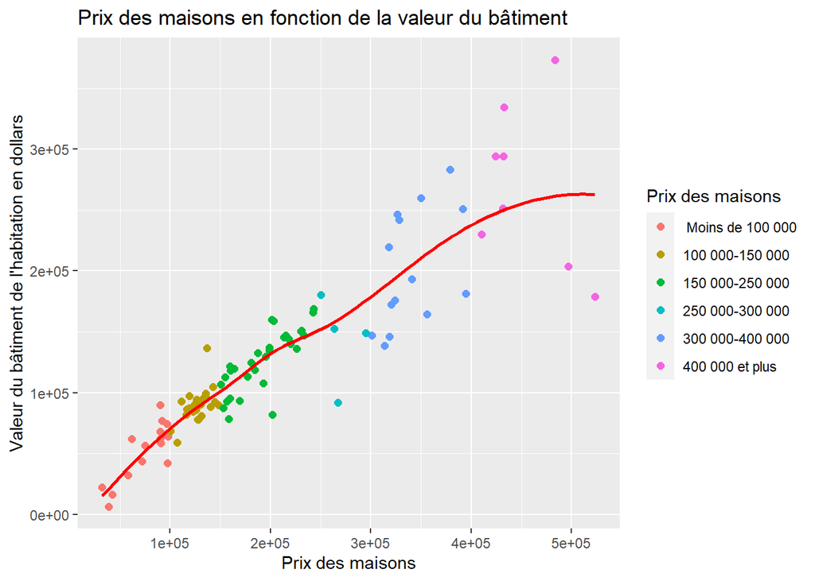

```
##   Corrélation générale Avant 1982 Après 1982
## 1                0.901      0.873      0.967
```

## Comment la valeur de l’habitation évolue par rapport a la surface totale (en demi hectare)?

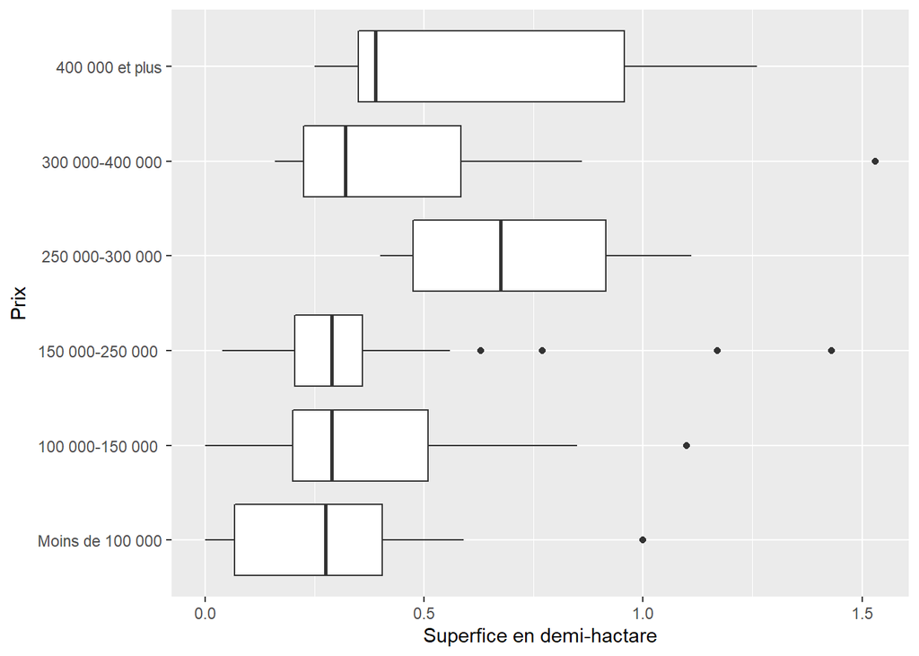

```
##   Corrélation générale Avant 1982 Après 1982
## 1                0.238      0.126       0.32
```

#### D’après nos résultats, on constate une faible corrélation entre la valeur de l’habitation et sa surface totale. En effet la corrélation générale est égale à 0.238, tandis que la valeur de la corrélation après 1982 est plus grande que celle d’avant 1982 (0.32 contre 0.126). Ce qui nous laisse conclure qu’il y a une évolution de la surface totale au fil des années.

## Comment la valeur de l’habitation évolue par rapport au nombre d’étage de la propriétée?

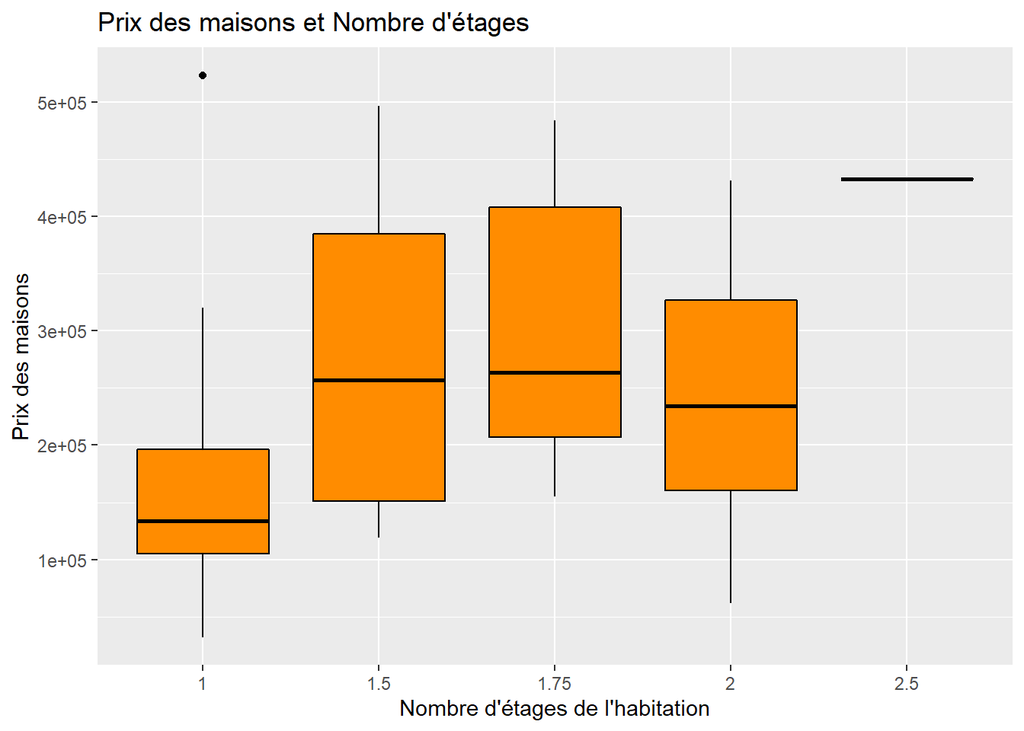

```
##
##                       1 1.5 1.75   2 2.5
##    Moins de 100 000  23   0    0  12   0
##   100 000-150 000    36  30    0   8   0
##   150 000-250 000    30  20   43  38   0
##   250 000-300 000     4   0   14   4   0
##   300 000-400 000     5  30   14  29   0
##   400 000 et plus     2  20   29   8 100
```

#### Nous avons réalisé ci-dessous les boites à moustache du prix des maisons en fonction du nombre d’étages par habitation. Les valeurs des habitations à un étage semble légèrement inférieur aux autres.En effet, plus le prix de l’habitation augmente plus le nombre d’habitation à un étage diminue.Cependant, au delà de un les prix reste dans les même tranches. Avoir plus ou moins d’étage ne semble pas avoir une grande influence sur la valeur des logements hormis pour les habitations d’un étage.

## Le nombre de salle de bain par habitation influe t-il à la hausse sur le prix de l’habitation ?

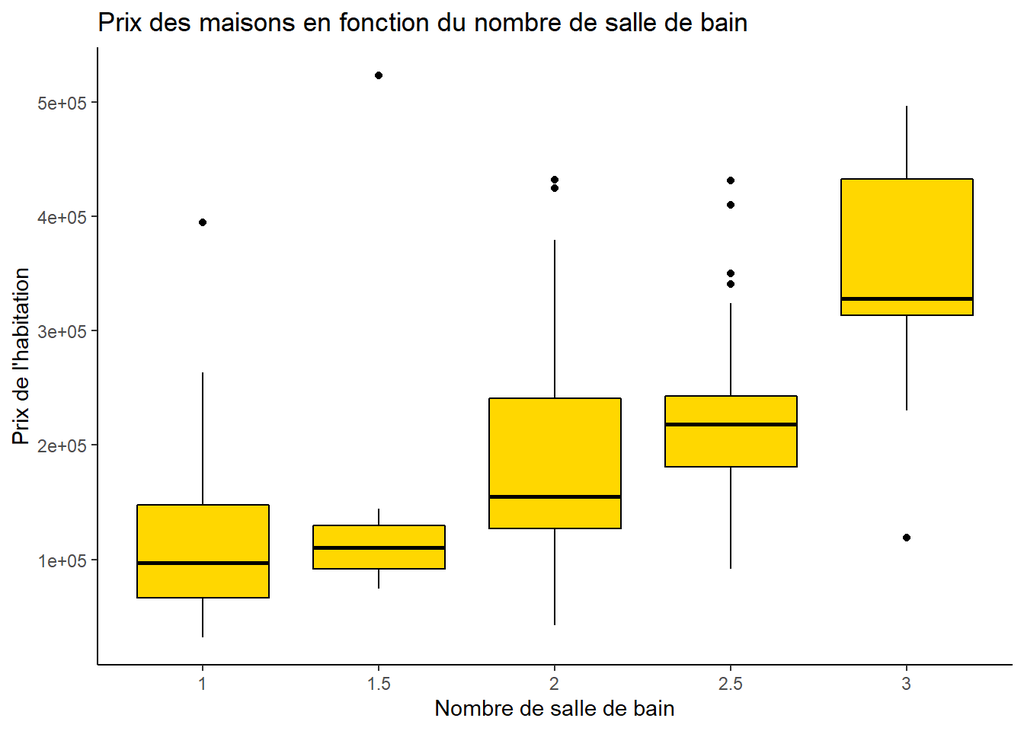

```
##
##                      1 1.5  2 2.5  3
##    Moins de 100 000 50  31 12   6  0
##   100 000-150 000   12  16 60   8  4
##   150 000-250 000    6   0 39  52  3
##   250 000-300 000   25   0 50  25  0
##   300 000-400 000    7   0 43  21 29
##   400 000 et plus    0  12 25  25 38
```

#### Il semble avoir un lien entre le nombre de salle de bain et le prix de l’habitation. En effet 50% des maisons qui coutent moins de 100000 dollars possèdent une seule salle de bain. A l’opposé seulement 7% des maisons qui possèdent une valeur entre 300000 et 400000 dollards n’ont qu’une seule salle de bain. Le nombre de salle de bains influe donc sur le prix des habitations.

## Création d’un modèle statistique

### modèle linéaire complet

```
##
## Call:
## lm(formula = Total ~ ., data = wakecounty2)
##
## Residuals:
##     Min      1Q  Median      3Q     Max
## -115333  -21352   -1232   16785  203880
##
## Coefficients:
##               Estimate Std. Error t value Pr(>|t|)
## (Intercept)  3.690e+06  5.792e+05   6.370 7.83e-09 ***
## YearBuilt   -1.880e+03  2.981e+02  -6.306 1.04e-08 ***
## SqFt        -2.365e+01  1.576e+01  -1.500   0.1370
## Story       -8.874e+03  1.251e+04  -0.709   0.4799
## Acres        2.480e+04  1.442e+04   1.720   0.0889 .
## NoBaths      2.209e+04  1.063e+04   2.077   0.0406 *
## Fireplaces   6.422e+03  1.158e+04   0.555   0.5804
## Building     1.711e+00  1.515e-01  11.295  < 2e-16 ***
## ---
## Signif. codes:  0 '***' 0.001 '**' 0.01 '*' 0.05 '.' 0.1 ' ' 1
##
## Residual standard error: 41320 on 90 degrees of freedom
## Multiple R-squared:  0.8773, Adjusted R-squared:  0.8678
## F-statistic: 91.94 on 7 and 90 DF,  p-value: < 2.2e-16
```

### La p-valeur du test de Fisher est très significative, donc on rejette l’hypothèse H0 modele null contre H1 modèle complet. On observe un R² ajusté de 0.8678 ce qui est plutôt élevé, cela signifie que nos variables expliques 86.78 % de la variance du prix des habitations. De nombreuse variables ont des coefficients qui ne sont pas significativement différent de 0 on peut essayer defaire de la selection de variable.

### On realise un modèle avec plusieurs critères (BIC,Cp,R²).

####On obtient de les graphique suivants :

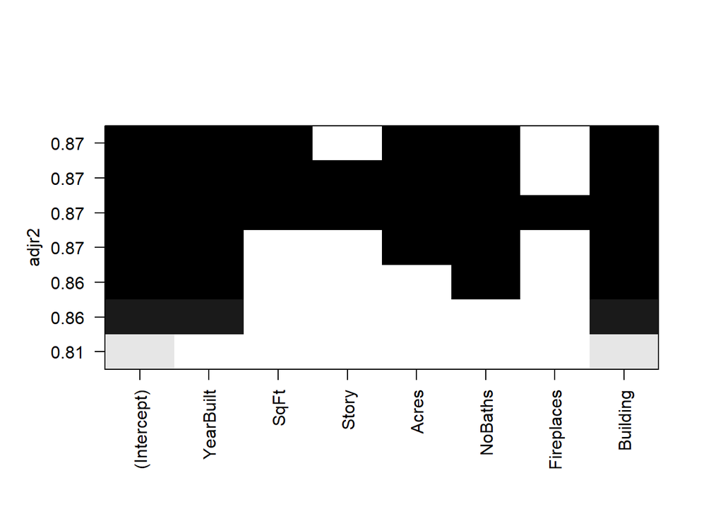

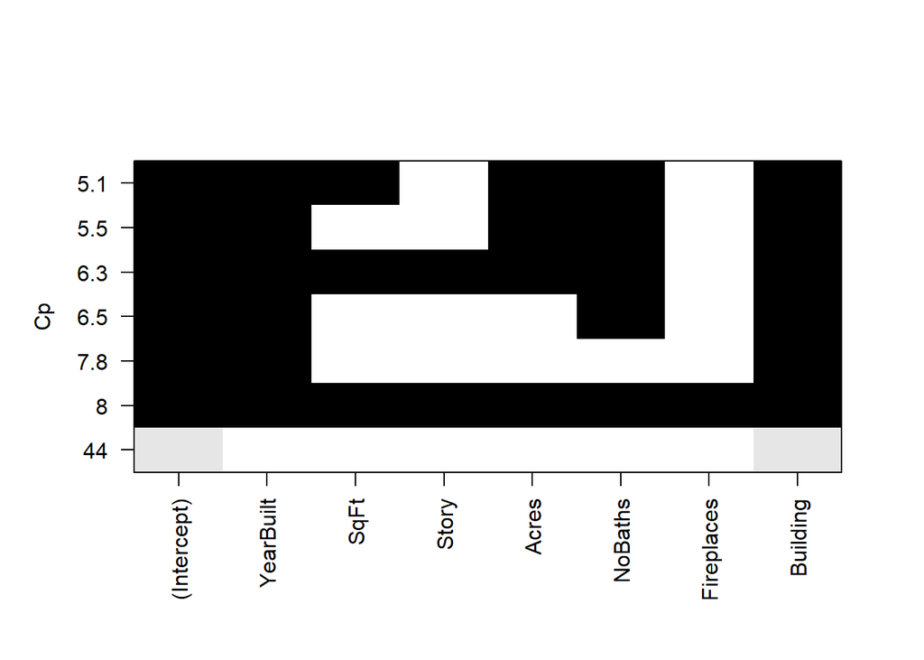

```
##   (Intercept)     YearBuilt          SqFt         Acres       NoBaths
##  3.797991e+06 -1.939096e+03 -2.426935e+01  2.849003e+04  2.355132e+04
##      Building
##  1.699381e+00
```

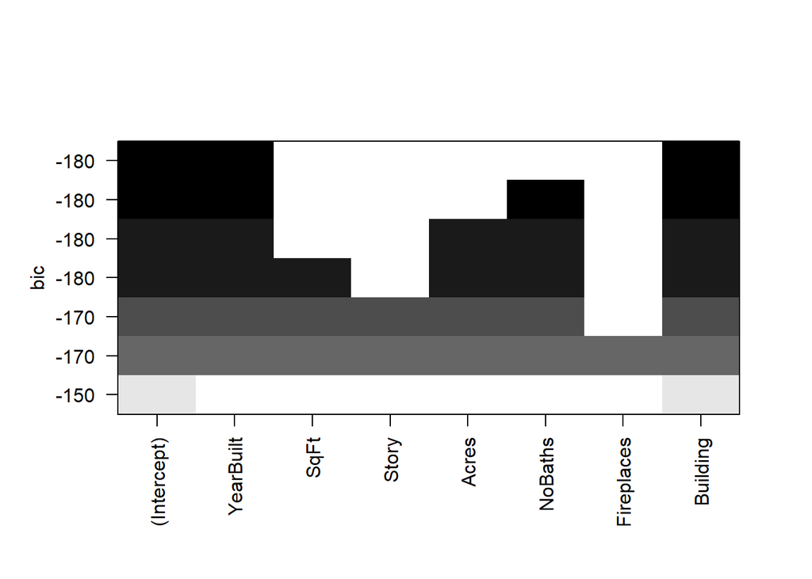

```
##   (Intercept)     YearBuilt      Building
##  3.269802e+06 -1.656720e+03  1.604799e+00
```

#### Le critère du R² ajusté retient 5 coefficents, il n’incorpore pas le nombre de cheminée(Fireplaces) et le nombre d’étage(Story).

#### Le critère du BIC lui retient seulement 2 variables la valeur du bâtiment de l’habitation en dollars(Building) et l’année de construction de l’habitation(YearBuilt). Il nous faut maintenant comparer les deux modèles.

```
## Analysis of Variance Table
##
## Model 1: Total ~ YearBuilt + Building
## Model 2: Total ~ YearBuilt + SqFt + Acres + NoBaths + Building
##   Res.Df        RSS Df  Sum of Sq      F Pr(>F)
## 1     95 1.7034e+11
## 2     92 1.5559e+11  3 1.4753e+10 2.9078 0.0388 *
## ---
## Signif. codes:  0 '***' 0.001 '**' 0.01 '*' 0.05 '.' 0.1 ' ' 1
```

```
## [1] 0.8757982
```

#### On peut voir que le meilleur modèle n’incluent pas les variables Story et Fireplaces. D’après l’anova le modèle du R² est légérement meilleur, cependant si l’agent immobilier n’a que très peu de données, le modèle du BIC sera une bonne alternative.

#### Le modèle du R² ajusté est le suivant:

$$Y_i = Ei + \beta + \sum{k=1}^{5} \alpha_k * x_ki$$
où $Y_i$ est la valeur de l’habitation à estimer, les $x_k$ sont les variables du modèle, $\alpha_k$ les coefficients des variables et $E_i$ sont iid et suivent une loi $N(0,\sigma^2)$.

```
##    Prix estimé Prix réel
## 1   227757.107    203200
## 2   142084.062    119096
## 3    94067.642     71666
## 4   129106.035    131103
## 5   141969.462    144452
## 6   447104.281    496425
## 7   142066.207    169187
## 8   239535.685    243092
## 9   496283.762    432516
## 10  176572.280    192794
## 11    1307.084     58116
## 12  351892.474    394694
## 13  162445.057    135298
## 14  144337.656    124355
```

[output cut: 84 more lines]

#### La prédiction n’est pas parfaite. Certaines valeurs sont bien prédits d’autres sont très éloignées.

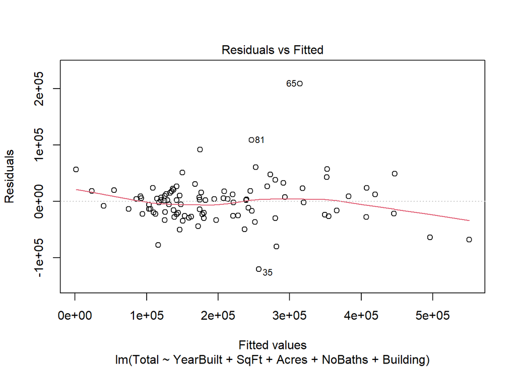

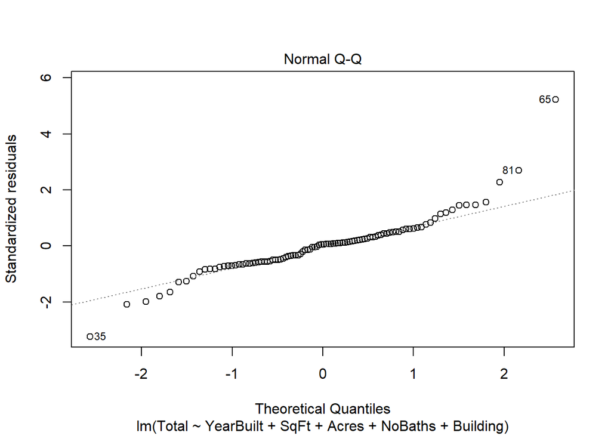

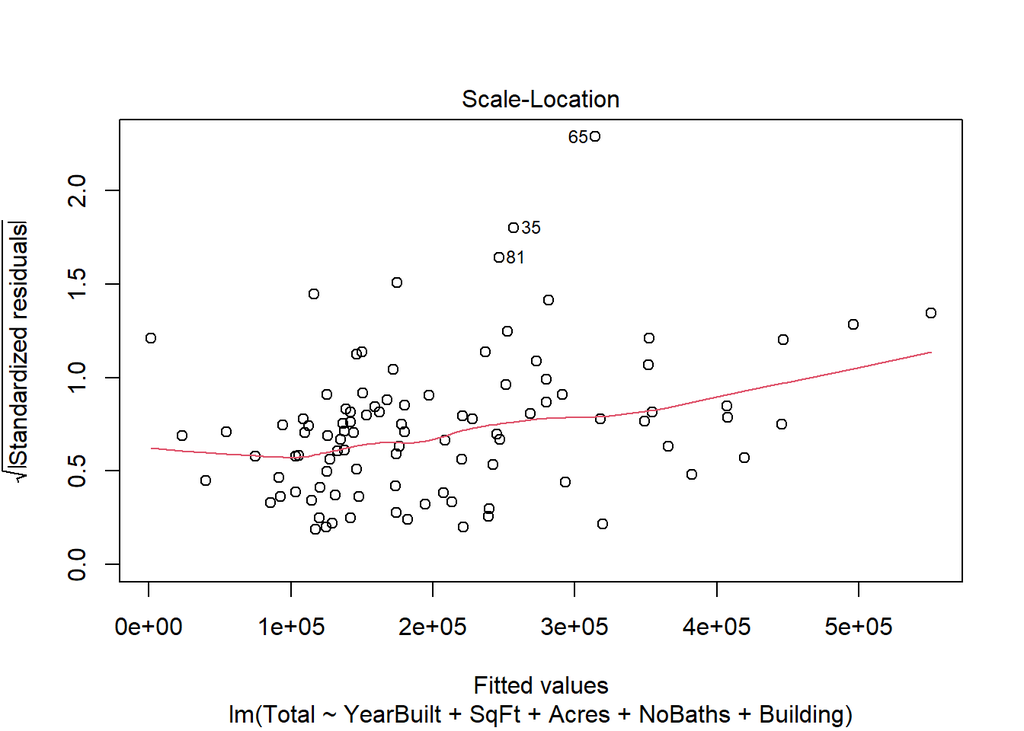

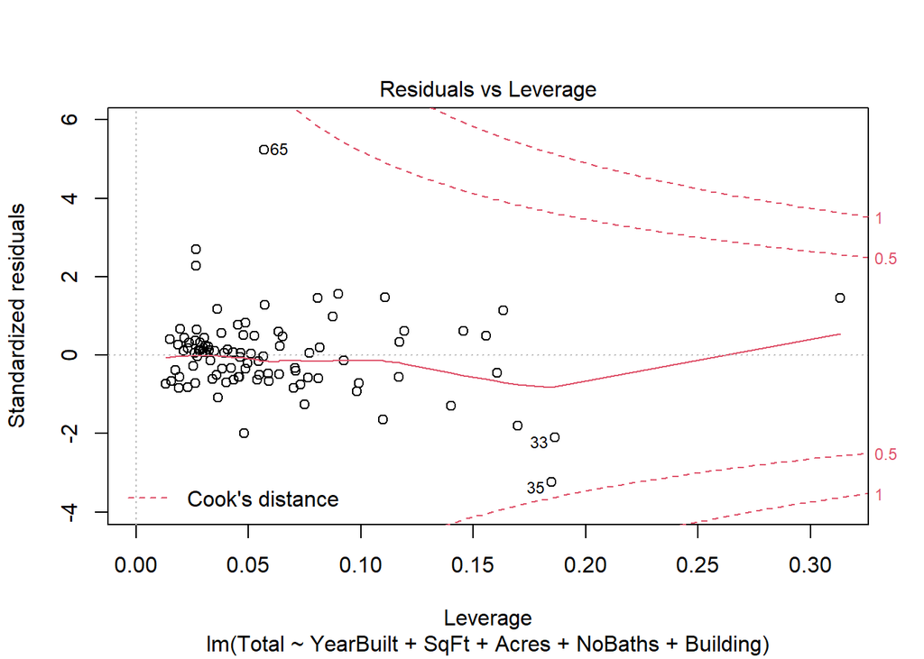

#### Pour residual vs fitted on voit un peu l’effet de la moyenne. Pour le qqplot à part pour les extrèmes ce semble correcte,pour scale location certaines vaaleurs sont très éloignés comme le numéro 65. Pour residuals vs Leverage, on a aussi certains points abhérents.

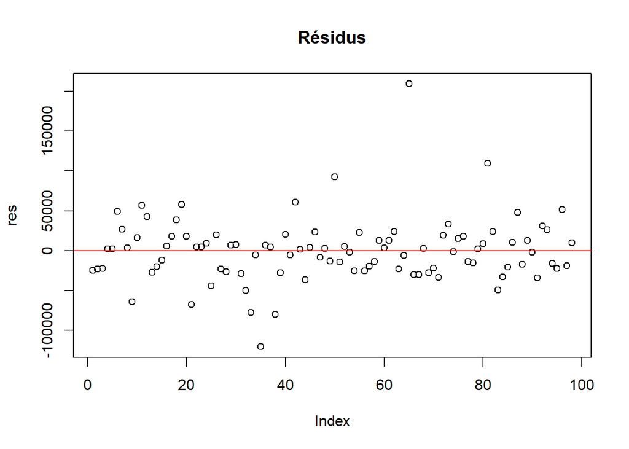

#### Les résidus semblent assez bien répartis.L’écart-type résiduel est une mesure de la qualité de l’ajustement qui peut être utilisée pour analyser dans quelle mesure un ensemble de points de données correspond au modèle réel. Ici, l’écart type résiduel est de 41 120. Cependant, la variable SqFt est négative ce qui est étrange, il serait intéressant de tester d’autre modèle.

#### Nous allons essayé d’utiliser un ajustement polynomial de degré 2 pour une meilleur qualité d’ajustement.

```
##
## Call:
## lm(formula = Total ~ Building + I(Building^2) + YearBuilt + I(YearBuilt^2),
##     data = wakecounty2)
##
## Residuals:
##     Min      1Q  Median      3Q     Max
## -135995  -23586   -3486   16867  186329
##
## Coefficients:
##                  Estimate Std. Error t value Pr(>|t|)
## (Intercept)     1.574e+07  3.907e+07   0.403 0.687913
## Building        2.377e+00  2.106e-01  11.286  < 2e-16 ***
## I(Building^2)  -2.293e-06  6.040e-07  -3.797 0.000261 ***
## YearBuilt      -1.438e+04  3.980e+04  -0.361 0.718633
## I(YearBuilt^2)  3.233e+00  1.014e+01   0.319 0.750463
## ---
## Signif. codes:  0 '***' 0.001 '**' 0.01 '*' 0.05 '.' 0.1 ' ' 1
##
## Residual standard error: 39750 on 93 degrees of freedom
## Multiple R-squared:  0.8827, Adjusted R-squared:  0.8777
## F-statistic:   175 on 4 and 93 DF,  p-value: < 2.2e-16
```

```
##
## Call:
## lm(formula = Total ~ Building + I(Building^2) + YearBuilt + I(YearBuilt^2) +
##     Acres + I(Acres^2) + NoBaths + I(NoBaths^2) + SqFt + I(SqFt^2),
##     data = wakecounty2)
##
## Residuals:
##    Min     1Q Median     3Q    Max
## -97072 -21821  -1518  13859 184856
##
## Coefficients:
##                  Estimate Std. Error t value Pr(>|t|)
## (Intercept)     2.851e+06  4.018e+07   0.071   0.9436
## Building        1.833e+00  3.738e-01   4.904 4.33e-06 ***
## I(Building^2)   4.354e-08  1.177e-06   0.037   0.9706
## YearBuilt      -1.242e+03  4.094e+04  -0.030   0.9759
## I(YearBuilt^2) -1.282e-01  1.043e+01  -0.012   0.9902
## Acres           8.457e+04  4.257e+04   1.986   0.0501 .
## I(Acres^2)     -4.967e+04  3.080e+04  -1.613   0.1104
## NoBaths        -1.137e+04  5.221e+04  -0.218   0.8281
## I(NoBaths^2)    6.483e+03  1.303e+04   0.497   0.6202
## SqFt            8.200e+01  5.274e+01   1.555   0.1237
## I(SqFt^2)      -2.885e-02  1.370e-02  -2.106   0.0381 *
## ---
## Signif. codes:  0 '***' 0.001 '**' 0.01 '*' 0.05 '.' 0.1 ' ' 1
##
## Residual standard error: 38690 on 87 degrees of freedom
## Multiple R-squared:  0.896,  Adjusted R-squared:  0.8841
## F-statistic: 74.98 on 10 and 87 DF,  p-value: < 2.2e-16
```

```
## Analysis of Variance Table
##
## Model 1: Total ~ Building + I(Building^2) + YearBuilt + I(YearBuilt^2)
## Model 2: Total ~ Building + I(Building^2) + YearBuilt + I(YearBuilt^2) +
##     Acres + I(Acres^2) + NoBaths + I(NoBaths^2) + SqFt + I(SqFt^2)
## Model 3: Total ~ YearBuilt + SqFt + Acres + NoBaths + Building
## Model 4: Total ~ YearBuilt + Building
##   Res.Df        RSS Df   Sum of Sq      F   Pr(>F)
## 1     93 1.4693e+11
## 2     87 1.3025e+11  6  1.6684e+10 1.8573 0.097334 .
## 3     92 1.5559e+11 -5 -2.5343e+10 3.3856 0.007662 **
## 4     95 1.7034e+11 -3 -1.4753e+10 3.2848 0.024553 *
## ---
## Signif. codes:  0 '***' 0.001 '**' 0.01 '*' 0.05 '.' 0.1 ' ' 1
```

#### Avec un ajustement polynomial de degré 2 , d’après l’anova le meilleur modèle le suivant :

```
##    (Intercept)       Building  I(Building^2)      YearBuilt I(YearBuilt^2)
##   1.574426e+07   2.377140e+00  -2.293419e-06  -1.438372e+04   3.232822e+00
```

### Test du modèle en condition

```
##
## Call:
## lm(formula = Total ~ Building + I(Building^2) + YearBuilt + I(YearBuilt^2),
##     data = wake)
##
## Residuals:
##     Min      1Q  Median      3Q     Max
## -125845  -18628   -2435   16483  103339
##
## Coefficients:
##                  Estimate Std. Error t value Pr(>|t|)
## (Intercept)     2.853e+07  4.196e+07   0.680  0.49944
## Building        2.321e+00  2.341e-01   9.913 7.62e-14 ***
## I(Building^2)  -2.236e-06  6.567e-07  -3.405  0.00124 **
## YearBuilt      -2.757e+04  4.280e+04  -0.644  0.52213
## I(YearBuilt^2)  6.635e+00  1.092e+01   0.608  0.54579
## ---
## Signif. codes:  0 '***' 0.001 '**' 0.01 '*' 0.05 '.' 0.1 ' ' 1
##
## Residual standard error: 37050 on 55 degrees of freedom
## Multiple R-squared:  0.8967, Adjusted R-squared:  0.8892
## F-statistic: 119.4 on 4 and 55 DF,  p-value: < 2.2e-16
```

```
##    Prix estimé Prix réel
## 1    412493.63    432023
## 2    118626.61    132597
## 3    184402.31    154726
## 4     84708.39     97300
## 5    325510.83    523366
## 6    271269.48    250180
## 7    177540.16    150637
## 8    251667.89    242102
## 9    405878.44    379166
## 10   418548.54    424333
## 11   192978.43    163800
## 12   -27729.80     42193
## 13   278312.28    324032
## 14   107807.42    115865
```

[output cut: 24 more lines]

#### Erreur absolue moyenne et erreur quadratique moyenne

```
## [1] 26430.12
```

```
## [1] 39106.82
```

#### D’après les résultats notre modèle semble très bien.

####Cependant, il aurait été intéressant d’essayer avec encore d’autre modèles pour obtenir un modèle optimale.

# Synthèse :

##### La population du jeu de données est assez hétérogènes ce qui ne facilite pas la création du modèle.

#### D’après notre étude, les variables qui influent le plus sur le prix d’habitation sont : la superficie du terrain(Acres), la superficie de l’habitation(SqFt), la valeur du bâtiment de l’habitation(Building), le nombre de salle de bain(NoBaths) et l’année de construction(YearBuilt).

#### Cependant, certaines variables sont plus détermiantes que d’autres c’est le cas que la valeur du bâtiment de l’habitation(Building) et l’année de construction(YearBuilt). Il aurait pu être intéressant de créer un modèle pour les maisons anciennes et pour les maisons plus récente, ou bien un modèle en fonction du quartier d’habitation ou du type d’habitation.

#### Un modèle pour expliquer le prix d’une habitation reste très limité car la valeur d’un bien fluctue. De plus, notre modèle et notre base de données ne prennent pas en compte de nombreux paramètres essentiels tels que l’inflation, la parité des monnaies, l’étage précis, les aménagements prévus, le voisinage, le taux d’emploi, le type de bâtiment, le paysage, le bruit, la qualité du bâtiment, l’état du bâtiment …

#### Par exemple, le fait de ne pas savoir si l’habitation est un appartement ou une maison est compliqué puisqu’on fait des biais en se disant “un étage égale un appartement” alors qu’il existe des duplexes et des mobylomes. De même, il semble que les habitations proches de Raleigh sont majoritairement des maisons.